# How did storms affect the health and economy in U.S.?

Yoshiteru Kageyama

August 21, 2015

## Synopsis

This analysis describes how storms and other severe weather events have caused both public health and economic problems in the U.S. communities. I got the storm data from the U.S. National Oceanic and Atmospheric Administration’s(NOAA) storm database. I also tried tidying them up, as they contained ambiguous and incorrect data in the several data fields. In this analysis, **tornado** is the most harmful weather event to people in the U.S.. Tornado is much more harmful than any other weather event in the U.S. so far. **Flood**, on the other hand, affects its crop and properties.

## Data Processing

The data for this assignment come in the form of a CSV file which was compressed with bzip2. I downloaded it via the RStudio environment and uncompressed it. I also prepared for several R packages that were useful for the data processing and visualization.

```r
# Set several Internet options
setInternet2(TRUE)
local({
  r <- getOption("repos")
  r["CRAN"] <- 'http://ftp.yz.yamagata-u.ac.jp/pub/cran/'
  options(repos = r)
})

# Download the necessary R packages, if they don't exist in the system.
reqPkgs <- c("ggplot2", "dplyr", "tidyr")

for(p in reqPkgs) {
  if (!p %in% installed.packages()){
    install.packages(p)
  }
  library(p, character.only = TRUE)
}
# Download the storm event data.
stormDataUrl <- 'https://d396qusza40orc.cloudfront.net/repdata%2Fdata%2FStormData.csv.bz2'
compStormData <- 'StormData.csv.bz2'
stormData <- 'StormData.csv'
if (!file.exists(compStormData)) {
  download.file(stormDataUrl, compStormData)
}

# Uncompress them, if the data haven't been uncompressed yet.
if (!(stormData %in% dir())) {
  print("Uncompressing data...")
  bunzip2(filename = compStormData, destname = stormData)
}
# Read the uncompressed csv data into data frame.
stormData.csv <- read.csv(file=stormData, header=TRUE)
```

### Tidying up EVTYPE data field

Since there are several strange data found in the EVTYPE field, they must be tidied up to compliant with the NOAA document.  
My strategy of cleaning the data is as follows:

- Try to correct obviously misspelled EVTYPEs (e.g., THUNDER’E’STORM…)
- Try to regard several abbreviations as original description of EVTYPE. (e.g., TSTM => Thunderstorm…)
- Other strange data can be ignored in this data analysis (i.e., they can remain as is).

```r
# Try to correct obviously misspelled EVTYPEs and abbreviations.
stormData.csv$EVTYPE = toupper(stormData.csv$EVTYPE)

# list of substitution rule.
subs <- list(c("^ *ASTRONOMICAL LOW TIDE *$", "ASTRONOMICAL LOW TIDE"),
             c("^ *(AVALANCHE|AVALANCE) *$", "AVALANCHE"),
             c("^ *(BLIZZARD (SUMMARY|WEATHER)?|BLIZZARD AND .*|BLIZZARD/.*) *$", "BLIZZARD"),
             c("^ *(COASTAL|CSTL) ?FLOOD(ING)?(/EROSION)? *$", "COASTAL FLOOD"),
             c("^ *(COLD/WIND CHILL (TEMPERATURE(S)?)?|COLD/WINDS) *$", "COLD/WIND CHILL"),
             c("^ *DENSE FOG *$", "DENSE FOG"),
             c("^ *DENSE SMOKE *$", "DENSE SMOKE"),
             c("^ *DROUGHT(/EXCESSIVE HEAT)? *$", "DROUGHT"),
             c("^ *DUST (DEVEL|DEVIL|DEVIL WATERSPOUT) *$", "DUST DEVIL"),
             c("^ *DUST ?STORM(/HIGH WINDS)? *$", "DUST STORM"),
             c("^ *EXCESSIVE HEAT(/DROUGHT)? *$", "EXCESSIVE HEAT"),
             c("^ *EXTREME (COLD)?/?(WIND\ ?CHILL(S)?)?( TEMPERATURES|/BLOWING SNO)? *$", "EXTREME COLD/WIND CHILL"),
             c("^ *(FLOOD(S|ING)?|FLOODING/HEAVY RAIN|FLOOD & HEAVY RAIN|FLOOD[ /]FLASH[ /]?FLOOD(ING)?|FLOOD/FLASH|FLOOD/RAIN/WIND(S)?|FLOOD/RIVER FLOOD|FLOOD/STRONG WIND) *$", "FLOOD"),
             c("^ *FREEZING FOG *$", "FREEZING FOG"),
             c("^ *(FROST|FROST/FREEZE|FROST\\\\\\FREEZE) *$", "FROST/FREEZE"),
             c("^ *(FUNNEL(S)?|FUNNEL CLOUD[.S]?|FUNNEL CLOUD/HAIL) *$", "FUNNEL CLOUD"),
             c("^ *(HAIL|HAIL[ \\(]?[0-9.]+\\)?|HAIL (ALOFT|DAMAGE|STORM|FLOODING|FORCE WINDS)|HAIL/ICY ROADS|HAIL/WIND(S)?|HAILSTORM(S)?|HAIL\\)) *$", "HAIL"),
             c("^ *(HEAT|HEAT (DROUGHT|WAVE(S| DROUGHT)?)|HEAT/DROUGHT|HEATBURST) *$", "HEAT"),
             c("^ *((HVY|HEAVY) RAIN(S)?(/|;|AND )?(.*)?|HEAVY RAIN EFFECTS|HEAVY RAINFALL) *$", "HEAVY RAIN"),
             c("^ *HEAVY( WET| LAKE)? SNOW(( ?(AND|/|&|-)| +)[A-Z /&]*)? *$", "HEAVY SNOW"),
             c("^ *HIGH SURF( ADVISOR(Y|IES))? *$", "HIGH SURF"),
             c("^ *HIGH WIND(S)?( +([0-9]+|\\([A-Z0-9]+\\)|AND.*)|/.*)", "HIGH WIND"),
             c("^ *HURRICANE(( [A-Z]+(/[A-Z ]+))|(-[A-Z ]+)|/TYPHOON( +[A-Z]+)?)?", "HURRICANE/TYPHOON"),
             c("^ *(ICE ?STORM((/[A-Z ]+)|( AND SNOW))?|ICE/[A-Z ]+) *$","ICE STORM"),
             c("^ *LAKE(SHORE)? FLOOD *$","LAKESHORE FLOOD"),
             c("^ *LAKE-?EFFECT SNOW *$","LAKE-EFFECT SNOW"),
             c("^ *(LIGHTING|LIGHTNING|LIGNTNING)([A-Z ./]+)?", "LIGHTNING"),
             c("^ *MARINE HAIL *$", "MARINE HAIL"),
             c("^ *MARINE HIGH WIND *$", "MARINE HIGH WIND"),
             c("^ *MARINE STRONG WIND *$", "MARINE STRONG WIND"),
             c("^ *MARINE (THUNDERSTORM|TSTM) WIND *$", "MARINE THUNDERSTORM WIND"),
             c("^ *RIP CURRENT(S([ /]HEAVY SURF)?)? *$", "RIP CURRENT"),
             c("^ *SEICHE *$", "SEICHE"),
             c("^ *(SLEET(/[A-Z /]+)?|SLEET (& )?[A-Z ]+) *$", "SLEET"),
             c("^ *STORM SURGE(/TIDE)? *$", "STORM SURGE/TIDE"),
             c("^ *STRONG WIND(S)?( GUST)? *$", "STRONG WIND"),
             c("^ *(THUNDERESTORM|THUNDERSTORM|THUNDERSTROM|THUNDERTORM|THUNDERSORM)(S)?(\\ +(WIND|W IND)(S)?([/ ]+[A-Z ]+)?)? *$", "THUNDERSTORM WINDS"),
             c("^ *(THUNERSTORM|THUNDERSTORM|THUNDESTORM|THUNDERTSORM)\\ *WIND(S)?\\ *(\\.|\\(?G[0-9]+\\)?|[0-9]+( ?MPH(\\.)?)?)? *$", "THUNDERSTORM WINDS"),
             c("^ *THUNDERSTORM(W)?(\\ ([0-9]+|WIND(S|SS)?|WINS))?", "THUNDERSTORM WINDS"),
             c("^ *THUNDERSTORM WINDS[A-Z ]+ *$", "THUNDERSTORM WINDS"),
             c("^ *TSTM\\ WIND\\ +\\(?G?[0-9]+\\)? *$", "THUNDERSTORM WINDS"),
             c("^ *TSTM (WIND(S)?|WND)(/[A-Z]+| [A-Z ]+)? *$", "THUNDERSTORM WINDS"),
             c("^ *TSTM(W) *$", "THUNDERSTORM WINDS"),
             c("^ *(TORNADO(S|ES)?|TORNAO|TORNDAO) *$", "TORNADO"),
             c("^ *TORNADO(\\ [A-Z0-9]+|/[A-Z]+|ES,[A-Z, ]+) *$", "TORNADO"),
             c("^ *TROPICAL DEPRESSION *$", "TROPICAL DEPRESSION"),
             c("^ *TROPICAL STORM(\\ +[A-Z]+)? *$", "TROPICAL STORM"),
             c("^ *TSUNAMI *$", "TSUNAMI"),
             c("^ *VOLCANIC ASH(\\ ?[A-Z]+)? *$", "VOLCANIC ASH"),
             c("^ *(WATER|WAYTER) ?SPOUT(S)?((-[A-Z]*)?|/[A-Z ]*|\\ [A-Z ]+)? *$","WATERSPOUT"),
             c("^ *(WILD\\ ?FIRE(S)|WILD/FOREST FIRE(S)?) *$", "WILDFIRE"),
             c("^ *WINTER STORM(S)?([/ ]?[A-Z ]+)? *$","WINTER STORM"),
             c("^ *WINTER WEATHER([/ ]MIX)? *$","WINTER WEATHER")
             )

# Substitute matched data in EVTYPE data field
for (s in subs) {
    stormData.csv$EVTYPE = gsub(pattern = s[[1]],
                                replacement = s[[2]],
                                x = stormData.csv$EVTYPE)
}
```

### Calculate PROPDMG and CROPDMG data fields according to CROPDMGEXP/PROPDMGEXP.

Since there are CROPDMGEXP and PROPDMGEXP data fields in the storm data. We must calculate PROPDMG and CROPDMG data according to PROPDMGEXP and CROPDMGEXP data.

```r
library(dplyr)

# Tidying up the other data fields.
stormData.csv <- stormData.csv %>%
    mutate(INJURIES   = as.numeric(INJURIES),
           FATALITIES = as.numeric(FATALITIES),
           CROPDMG    = as.numeric(CROPDMG),
           PROPDMG    = as.numeric(PROPDMG),
           CROPDMG =
               ifelse(CROPDMGEXP == "K" | CROPDMGEXP == "k", CROPDMG * 1000,
                      ifelse(CROPDMGEXP == "M" | CROPDMGEXP == "m", CROPDMG * 1000000,
                             ifelse(CROPDMGEXP == "B" | CROPDMGEXP == "b", CROPDMG * 1000000000,
                                    CROPDMG))),
           PROPDMG =
               ifelse(PROPDMGEXP == "K" | PROPDMGEXP == "k", PROPDMG * 1000,
                      ifelse(PROPDMGEXP == "M" | PROPDMGEXP == "m", PROPDMG * 1000000,
                             ifelse(PROPDMGEXP == "B" | PROPDMGEXP == "b", PROPDMG * 1000000000,
                                    PROPDMG)))
    )
```

## Results

1. Across the United States, which types of events (as indicated in the EVTYPE variable) are most harmful with respect to population health?

```r
library(ggplot2)
library(tidyr)

# acquire only the data necessary to show how weather events affect human health,
# and aggregated them for each EVTYPE.
stormData.inj = select(stormData.csv, INJURIES, FATALITIES, EVTYPE)
stormData.inj = aggregate(. ~ EVTYPE, stormData.inj, sum)
stormData.inj <- mutate(stormData.inj, TOTAL_DAMAGED = INJURIES + FATALITIES) %>%
    filter(TOTAL_DAMAGED > 1000) %>%
    arrange(desc(TOTAL_DAMAGED)) %>%
    gather(DAMAGE_TYPE, NUM_INJ, INJURIES:FATALITIES)

head(stormData.inj, n = 10)
```

```
##                EVTYPE TOTAL_DAMAGED DAMAGE_TYPE NUM_INJ
## 1             TORNADO         97022    INJURIES   91364
## 2  THUNDERSTORM WINDS         10219    INJURIES    9508
## 3      EXCESSIVE HEAT          8428    INJURIES    6525
## 4               FLOOD          7301    INJURIES    6806
## 5           LIGHTNING          6049    INJURIES    5232
## 6                HEAT          3612    INJURIES    2494
## 7         FLASH FLOOD          2755    INJURIES    1777
## 8           ICE STORM          2066    INJURIES    1977
## 9            WILDFIRE          1696    INJURIES    1606
## 10       WINTER STORM          1570    INJURIES    1353
```

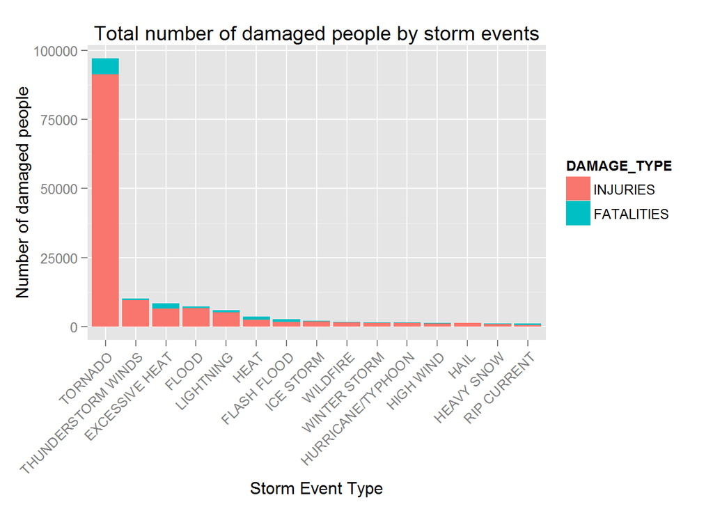

```r
# plot the stormData.
gp = ggplot(stormData.inj, aes(x = reorder(EVTYPE, -TOTAL_DAMAGED),
                               y = NUM_INJ, fill = DAMAGE_TYPE)) +
    geom_bar(stat = "identity") +
    xlab("Storm Event Type") +
    ylab("Number of damaged people") +
    ggtitle("Total number of damaged people by storm events") +
    theme(axis.text.x=element_text(angle=45,hjust=1))
plot(gp)
```

In this figure, **tornado, thunderstorm winds, excessive heat, flood, and lightning** are the top-5 most harmful weather events to people in the U.S..

2. Across the United States, which types of events have the greatest economic consequences?

```r
# acquire only the data necessary to show how weather events affect crop and
# properties in the U.S.
stormData.propdmg = select(stormData.csv, PROPDMG, CROPDMG, EVTYPE)
stormData.propdmg = aggregate(. ~ EVTYPE, stormData.propdmg, function(x) {
    total <- sum(x)
    return(total / 1000000000)
})
stormData.propdmg <- mutate(stormData.propdmg, TOTAL_DAMAGED = PROPDMG + CROPDMG) %>%
    filter(TOTAL_DAMAGED > 10) %>%
    arrange(desc(TOTAL_DAMAGED)) %>%
    gather(DAMAGE_TYPE, AMT_DMG, PROPDMG:CROPDMG)

head(stormData.propdmg, n = 10)
```

```
##                EVTYPE TOTAL_DAMAGED DAMAGE_TYPE    AMT_DMG
## 1               FLOOD     150.83623     PROPDMG 144.957519
## 2   HURRICANE/TYPHOON      86.63402     PROPDMG  81.274234
## 3             TORNADO      58.95939     PROPDMG  58.541932
## 4    STORM SURGE/TIDE      47.96558     PROPDMG  47.964724
## 5                HAIL      19.00056     PROPDMG  15.974470
## 6         FLASH FLOOD      17.56213     PROPDMG  16.140812
## 7             DROUGHT      15.01868     PROPDMG   1.046106
## 8  THUNDERSTORM WINDS      10.98825     PROPDMG   9.762791
## 9         RIVER FLOOD      10.14840     PROPDMG   5.118945
## 10              FLOOD     150.83623     CROPDMG   5.878708
```

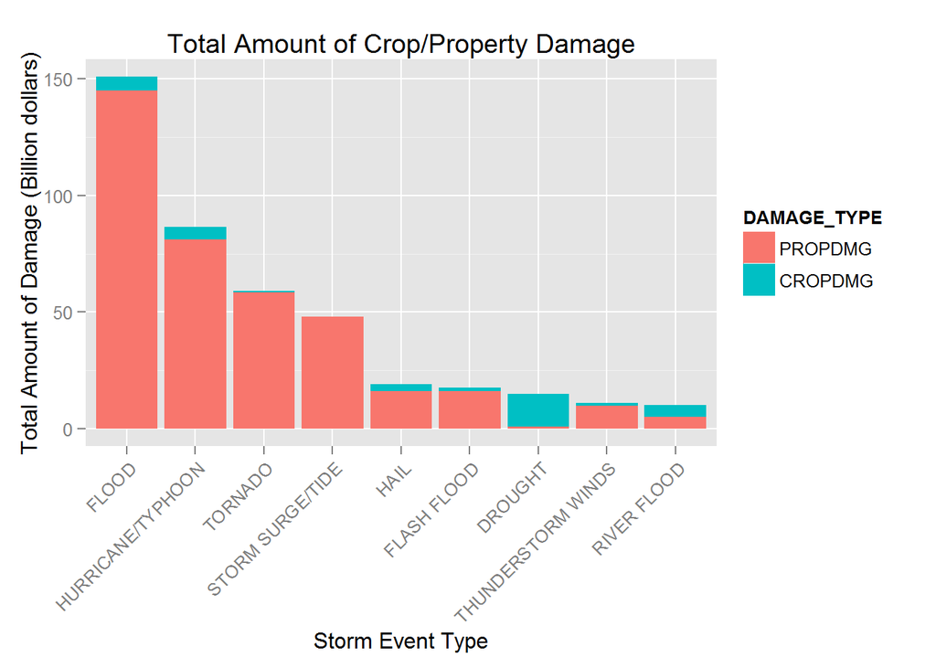

```r
# plot the storm data.
gp = ggplot(stormData.propdmg, aes(x = reorder(EVTYPE, -TOTAL_DAMAGED),
                               y = AMT_DMG, fill = DAMAGE_TYPE)) +
    geom_bar(stat = "identity") +
    xlab("Storm Event Type") +
    ylab("Total Amount of Damage (Billion dollars)") +
    ggtitle("Total Amount of Crop/Property Damage") +
    theme(axis.text.x=element_text(angle=45,hjust=1))
plot(gp)
```

In this figure, **flood** affects the crop and properties most in the U.S.